# PML Final Project

Jose Pereira

17 de Outubro de 2015

# Background

Using devices such as Jawbone Up, Nike FuelBand, and Fitbit it is now possible to collect a large amount of data about personal activity relatively inexpensively. These type of devices are part of the quantified self movement – a group of enthusiasts who take measurements about themselves regularly to improve their health, to find patterns in their behavior, or because they are tech geeks. One thing that people regularly do is quantify how much of a particular activity they do, but they rarely quantify how well they do it. In this project, your goal will be to use data from accelerometers on the belt, forearm, arm, and dumbell of 6 participants. They were asked to perform barbell lifts correctly and incorrectly in 5 different ways. More information is available from the website here: http://groupware.les.inf.puc-rio.br/har (see the section on the Weight Lifting Exercise Dataset).

# Goal of the project

The goal of your project is to predict the manner in which they did the exercise. This is the “classe” variable in the training set. You may use any of the other variables to predict with. You should create a report describing how you built your model, how you used cross validation, what you think the expected out of sample error is, and why you made the choices you did. You will also use your prediction model to predict 20 different test cases.

# Data Loading and Cleaning

I will first start by loading the data and defining all blank and badly coded variables as N.A

```r
train_data <- read.csv("pml-training.csv", sep=",", na.strings = c("", " ", "#DIV/0!","NA"))
test_data <- read.csv("pml-testing.csv", sep="," ,na.strings = c("", " ", "#DIV/0!","NA"))
```

I will then check the structure of both datasets

```r
str(train_data)
```

```
## 'data.frame':    19622 obs. of  160 variables:
##  $ X                       : int  1 2 3 4 5 6 7 8 9 10 ...
##  $ user_name               : Factor w/ 6 levels "adelmo","carlitos",..: 2 2 2 2 2 2 2 2 2 2 ...
##  $ raw_timestamp_part_1    : int  1323084231 1323084231 1323084231 1323084232 1323084232 1323084232 1323084232 1323084232 1323084232 1323084232 ...
##  $ raw_timestamp_part_2    : int  788290 808298 820366 120339 196328 304277 368296 440390 484323 484434 ...
##  $ cvtd_timestamp          : Factor w/ 20 levels "02/12/2011 13:32",..: 9 9 9 9 9 9 9 9 9 9 ...
##  $ new_window              : Factor w/ 2 levels "no","yes": 1 1 1 1 1 1 1 1 1 1 ...
##  $ num_window              : int  11 11 11 12 12 12 12 12 12 12 ...
##  $ roll_belt               : num  1.41 1.41 1.42 1.48 1.48 1.45 1.42 1.42 1.43 1.45 ...
##  $ pitch_belt              : num  8.07 8.07 8.07 8.05 8.07 8.06 8.09 8.13 8.16 8.17 ...
##  $ yaw_belt                : num  -94.4 -94.4 -94.4 -94.4 -94.4 -94.4 -94.4 -94.4 -94.4 -94.4 ...
##  $ total_accel_belt        : int  3 3 3 3 3 3 3 3 3 3 ...
##  $ kurtosis_roll_belt      : num  NA NA NA NA NA NA NA NA NA NA ...
##  $ kurtosis_picth_belt     : num  NA NA NA NA NA NA NA NA NA NA ...
##  $ kurtosis_yaw_belt       : logi  NA NA NA NA NA NA ...
```

[output cut: 86 more lines]

```r
str(test_data)
```

```
## 'data.frame':    20 obs. of  160 variables:
##  $ X                       : int  1 2 3 4 5 6 7 8 9 10 ...
##  $ user_name               : Factor w/ 6 levels "adelmo","carlitos",..: 6 5 5 1 4 5 5 5 2 3 ...
##  $ raw_timestamp_part_1    : int  1323095002 1322673067 1322673075 1322832789 1322489635 1322673149 1322673128 1322673076 1323084240 1322837822 ...
##  $ raw_timestamp_part_2    : int  868349 778725 342967 560311 814776 510661 766645 54671 916313 384285 ...
##  $ cvtd_timestamp          : Factor w/ 11 levels "02/12/2011 13:33",..: 5 10 10 1 6 11 11 10 3 2 ...
##  $ new_window              : Factor w/ 1 level "no": 1 1 1 1 1 1 1 1 1 1 ...
##  $ num_window              : int  74 431 439 194 235 504 485 440 323 664 ...
##  $ roll_belt               : num  123 1.02 0.87 125 1.35 -5.92 1.2 0.43 0.93 114 ...
##  $ pitch_belt              : num  27 4.87 1.82 -41.6 3.33 1.59 4.44 4.15 6.72 22.4 ...
##  $ yaw_belt                : num  -4.75 -88.9 -88.5 162 -88.6 -87.7 -87.3 -88.5 -93.7 -13.1 ...
##  $ total_accel_belt        : int  20 4 5 17 3 4 4 4 4 18 ...
##  $ kurtosis_roll_belt      : logi  NA NA NA NA NA NA ...
##  $ kurtosis_picth_belt     : logi  NA NA NA NA NA NA ...
##  $ kurtosis_yaw_belt       : logi  NA NA NA NA NA NA ...
```

[output cut: 86 more lines]

Since some NAs exist in the data in quite an abundant quantity, I decided to remove those columns that have more than 80% NAs

```r
train_data <- train_data[,colSums(is.na(train_data)) < nrow(train_data) * 0.8]
test_data <- test_data[,colSums(is.na(test_data)) < nrow(test_data) * 0.8]
```

Let’s remove the columns 1:5 which have data that seems to have no value for making a prediction model.

```r
train_data <- train_data[,-(1:5)]
test_data <- test_data[,-(1:5)]
```

# Model building

In this classification problem, we are mainly worried with accuracy and not the interpretability of the model so I decided to just implement a Random Forest algorithm which is one of the most accurate and efficient ones instead of doing classification trees or boosting algorithms. I will start by setting a seed and loading the caret package and splitting the train_data in a proportion of 70% (the training data) and 30% (a validation set to test the data before applying it to the test data given by professor Leek).

```r
set.seed(19)
library(caret)
in_train <- createDataPartition(y=train_data$classe, p = 0.7, list=FALSE)
training <- train_data[in_train,]
inside_testing <- train_data[-in_train,]
```

I will now build a Random Forest model with all variables as predictors using a 4-fold cross validation (will be quicker and Random Forest algorithm doesn’t need a really decent cross-validation as it is very resillient by itself)

```r
set.seed(14)
nf  <- trainControl(method="cv", number = 4)
RFmodel <- train(classe ~ .,
                 data=training,
                 method="rf",
                 importance = TRUE,
                 trControl = nf)
```

Let us check the model data, its accuracy and error rate and make a plot of the model. We will also test its accuracy on the validation test data

```r
RFmodel$finalModel
```

```
##
## Call:
##  randomForest(x = x, y = y, mtry = param$mtry, importance = TRUE)
##                Type of random forest: classification
##                      Number of trees: 500
## No. of variables tried at each split: 28
##
##         OOB estimate of  error rate: 0.21%
## Confusion matrix:
##      A    B    C    D    E  class.error
## A 3905    0    0    0    1 0.0002560164
## B    5 2650    3    0    0 0.0030097818
## C    0    3 2393    0    0 0.0012520868
## D    0    0    9 2242    1 0.0044404973
## E    0    0    0    7 2518 0.0027722772
```

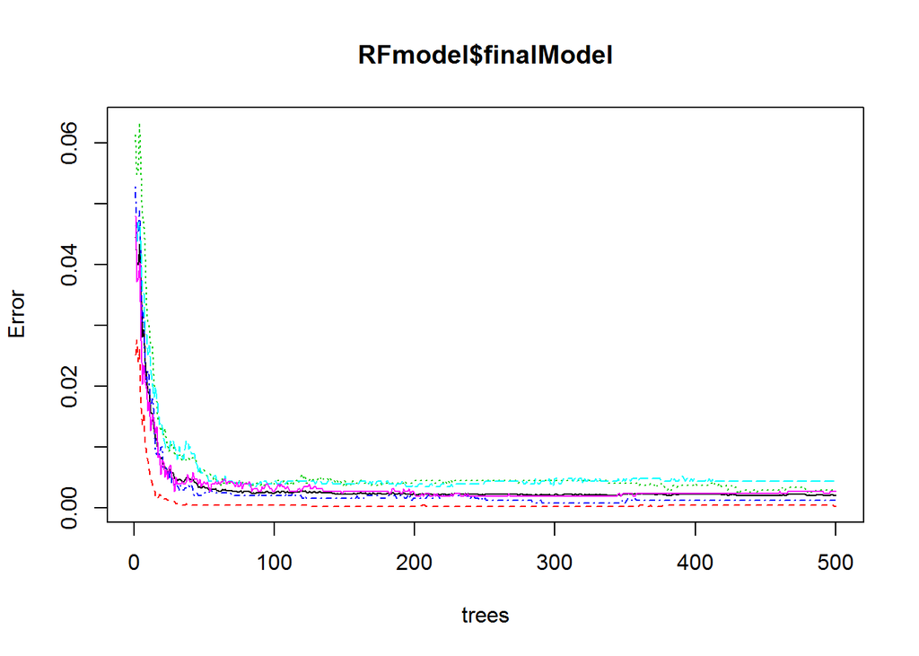

```r
plot(RFmodel$finalModel)
```

```r
predRF <- predict(RFmodel, inside_testing)

confusionMatrix(predRF, inside_testing$classe)
```

```
## Confusion Matrix and Statistics
##
##           Reference
## Prediction    A    B    C    D    E
##          A 1674    1    0    0    0
##          B    0 1138    6    0    0
##          C    0    0 1020    3    0
##          D    0    0    0  961    4
##          E    0    0    0    0 1078
##
## Overall Statistics
##
##                Accuracy : 0.9976
##                  95% CI : (0.996, 0.9987)
##     No Information Rate : 0.2845
##     P-Value [Acc > NIR] : < 2.2e-16
##
##                   Kappa : 0.997
##  Mcnemar's Test P-Value : NA
##
## Statistics by Class:
##
##                      Class: A Class: B Class: C Class: D Class: E
## Sensitivity            1.0000   0.9991   0.9942   0.9969   0.9963
## Specificity            0.9998   0.9987   0.9994   0.9992   1.0000
## Pos Pred Value         0.9994   0.9948   0.9971   0.9959   1.0000
## Neg Pred Value         1.0000   0.9998   0.9988   0.9994   0.9992
## Prevalence             0.2845   0.1935   0.1743   0.1638   0.1839
## Detection Rate         0.2845   0.1934   0.1733   0.1633   0.1832
## Detection Prevalence   0.2846   0.1944   0.1738   0.1640   0.1832
## Balanced Accuracy      0.9999   0.9989   0.9968   0.9980   0.9982
```

As we can see, the accuracy of this model on the training data validation set is quite good and its out of sample error rate is very low. Let us try to see the predictions in the test data of professor Leek.

```r
final_predictions_perfect <- predict(RFmodel, test_data)
final_predictions_perfect
```

```
##  [1] B A B A A E D B A A B C B A E E A B B B
## Levels: A B C D E
```

Considering the accuracy of this model, the only thing we can do now is to try to make the model creation faster by doing some feature editing and tuning some parameters. Let’s start by creating a plot of variable importance.

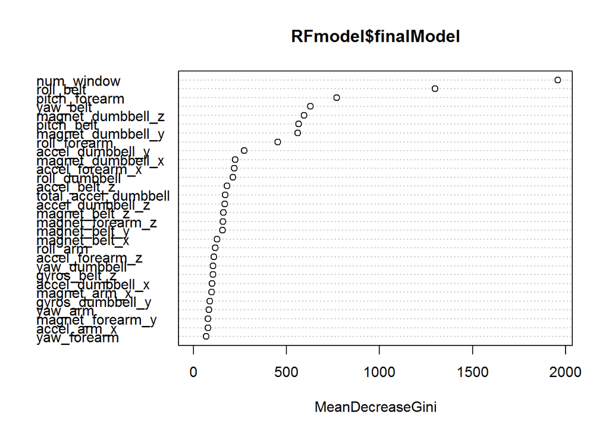

```r
varImpPlot(RFmodel$finalModel, type=2)
```

```r
tune <- expand.grid(mtry = 28)
RFmodel2 <- train(classe ~ num_window + roll_belt + pitch_forearm + yaw_belt + magnet_dumbbell_z + magnet_dumbbell_y + pitch_belt,
                  data = training,
                  method = "rf",
                  tuneGrid = tune,
                  ntree = 250, nodesize = 50)
```

I will now test the data on both the validation set and the test data of professor Leek to compare the results with the slower model.

```r
RFmodel2$finalModel
```

```
##
## Call:
##  randomForest(x = x, y = y, ntree = 250, mtry = param$mtry, nodesize = 50)
##                Type of random forest: classification
##                      Number of trees: 250
## No. of variables tried at each split: 7
##
##         OOB estimate of  error rate: 2.1%
## Confusion matrix:
##      A    B    C    D    E class.error
## A 3885   19    1    0    1 0.005376344
## B   19 2579   33   12   15 0.029721595
## C    3   33 2322   29    9 0.030884808
## D    4    1   21 2219    7 0.014653641
## E    6   34   22   20 2443 0.032475248
```

```r
RFmodel2
```

[output not shown]

```r
predictions_inside_testing <- predict(RFmodel2, inside_testing)
confusionMatrix(predictions_inside_testing, inside_testing$classe)
```

```
## Confusion Matrix and Statistics
##
##           Reference
## Prediction    A    B    C    D    E
##          A 1668    4    0    5    3
##          B    6 1119   18    0    8
##          C    0   11  990    9    4
##          D    0    1   15  950    6
##          E    0    4    3    0 1061
##
## Overall Statistics
##
##                Accuracy : 0.9835
##                  95% CI : (0.9799, 0.9866)
##     No Information Rate : 0.2845
##     P-Value [Acc > NIR] : < 2.2e-16
##
##                   Kappa : 0.9791
##  Mcnemar's Test P-Value : NA
##
## Statistics by Class:
##
##                      Class: A Class: B Class: C Class: D Class: E
## Sensitivity            0.9964   0.9824   0.9649   0.9855   0.9806
## Specificity            0.9972   0.9933   0.9951   0.9955   0.9985
## Pos Pred Value         0.9929   0.9722   0.9763   0.9774   0.9934
## Neg Pred Value         0.9986   0.9958   0.9926   0.9972   0.9956
## Prevalence             0.2845   0.1935   0.1743   0.1638   0.1839
## Detection Rate         0.2834   0.1901   0.1682   0.1614   0.1803
## Detection Prevalence   0.2855   0.1956   0.1723   0.1652   0.1815
## Balanced Accuracy      0.9968   0.9878   0.9800   0.9905   0.9896
```

```r
final_predictions_faster <- predict(RFmodel2, test_data)

final_predictions_perfect
```

```
##  [1] B A B A A E D B A A B C B A E E A B B B
## Levels: A B C D E
```

```r
final_predictions_faster
```

```
##  [1] B A B A A E D B A A B C B A E E A B B B
## Levels: A B C D E
```

We can see the accuracy and out of sample error of this model is not that different from the slower one and the test predictions are as accurate as those from the slower model, while being much faster to build. This proves how important it is to fine-tune the built models in order to gain the perfect balance between accuracy and speed.